# Compte Rendu

### Standard Minimal

Histogramme de 1000 valeurs générées par Standard Minimal avec une graine de 215

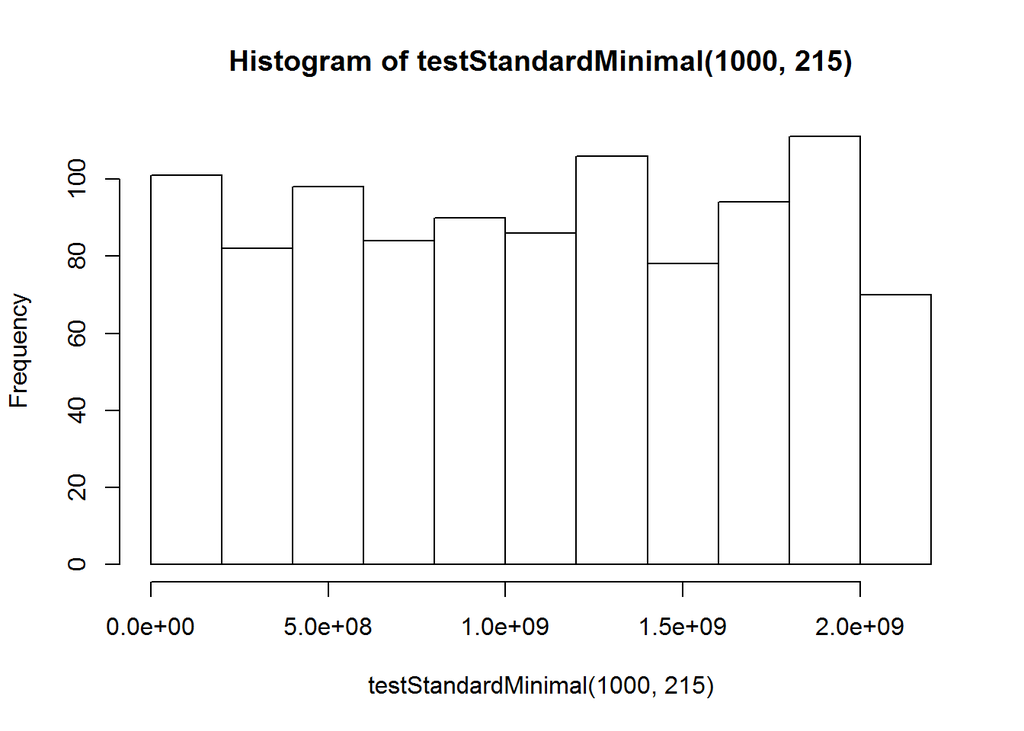

```r
hist(testStandardMinimal(1000, 215))
```

La répartition des valeurs est équlibrée et ne traduit pas de problème particulier.

### Mersenne-Twister

Histogramme de 1000 valeurs générées par Mersenne-Twister avec une graine de 215

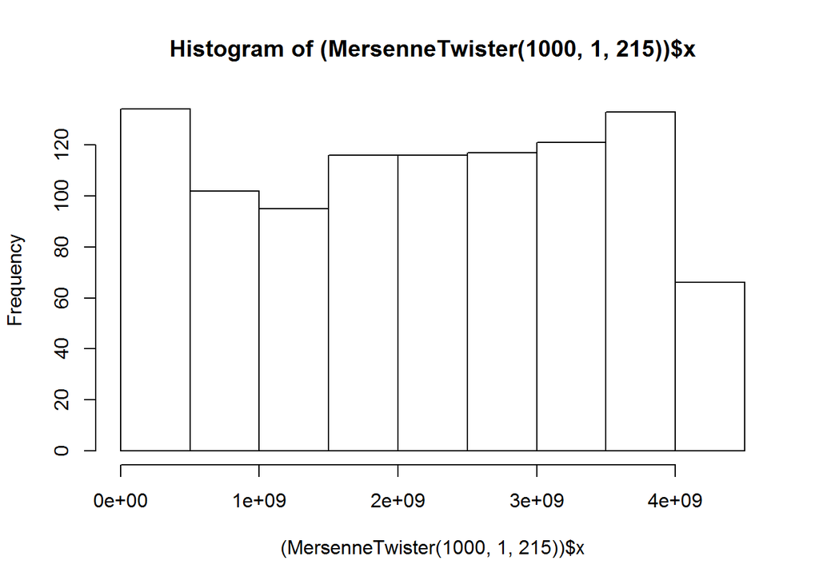

```r
hist((MersenneTwister(1000, 1, 215))$x)
```

La répartition des valeurs est équlibrée et ne traduit pas de problème particulier.

### Sobol

Histogramme de 1000 valeurs générées par Sobol

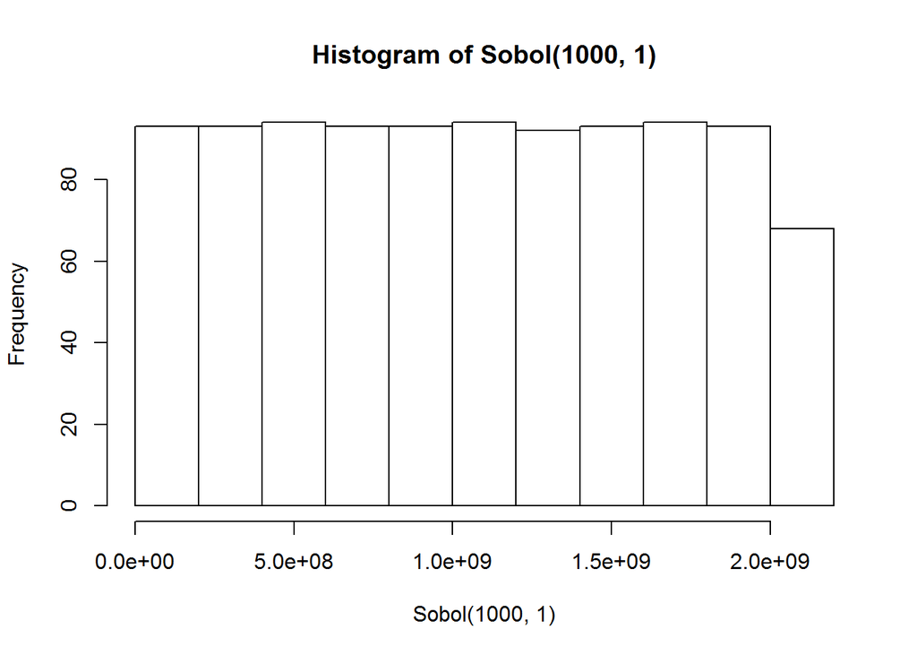

```r
hist(Sobol(1000, 1))
```

La répartition des valeurs est parfaitement équilibrée et semble même “trop” régulière.

## Question 2.2

Affichage de la valeur obtenue en fonction de la valeur précédente

### RANDU

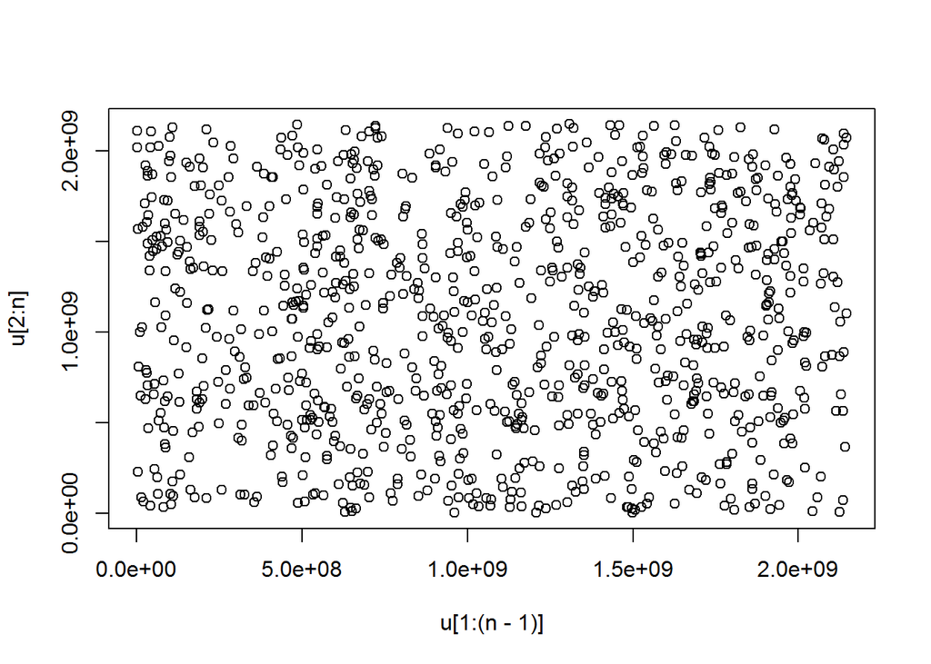

```r
n <- 1000
u <- testRANDU(n, 215)
plot(u[1:(n-1)], u[2:n])
```

### Standard Minimal

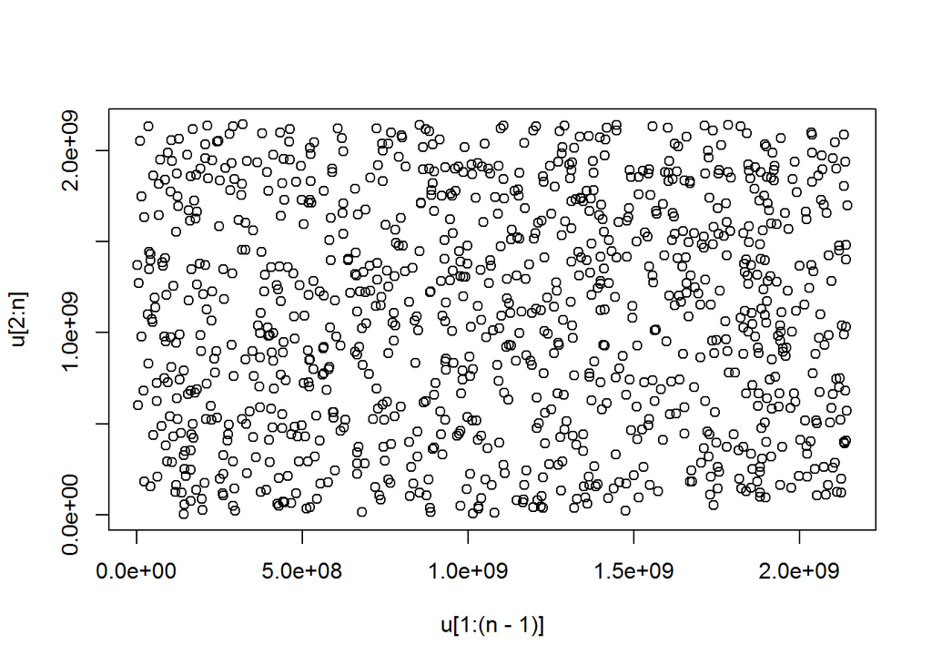

```r
n <- 1000
u <- testStandardMinimal(n, 215)
plot(u[1:(n-1)], u[2:n])
```

### Mersenne-Twister

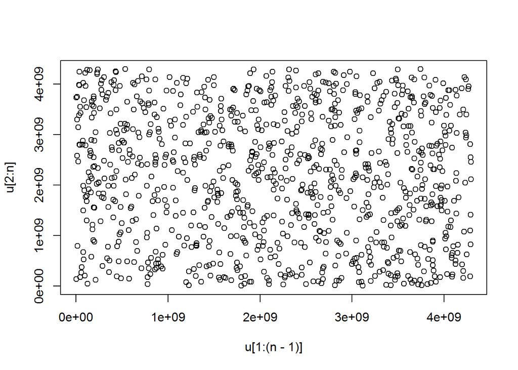

```r
n <- 1000
p <- 1
u <- (MersenneTwister(n, p, 215))$x
plot(u[1:(n-1)], u[2:n])
```

### Sobol

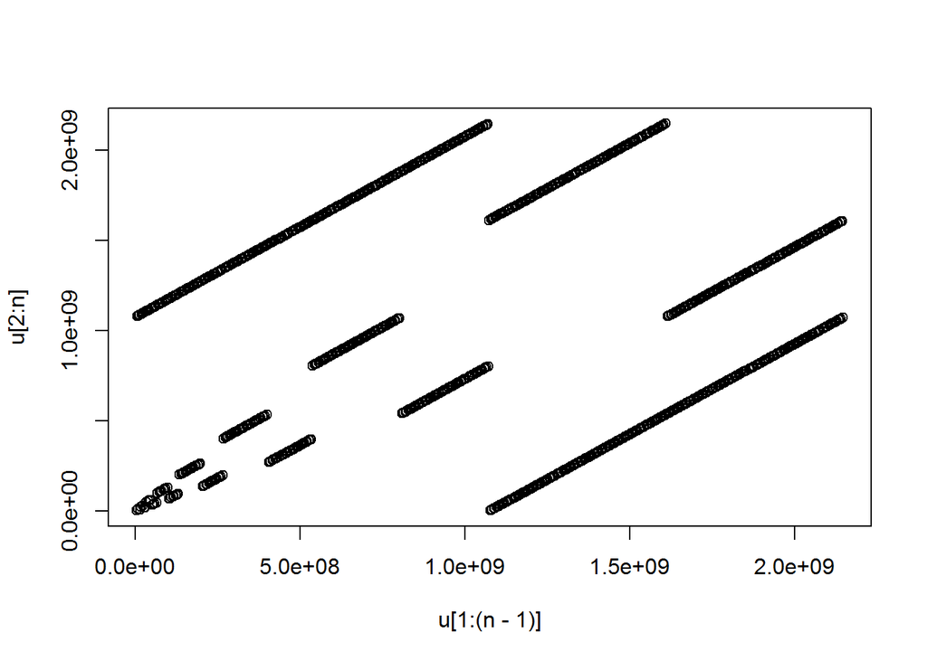

```r
n <- 1000
p <- 1
u <- Sobol(n, p)
plot(u[1:(n-1)], u[2:n])
```

### RANDU

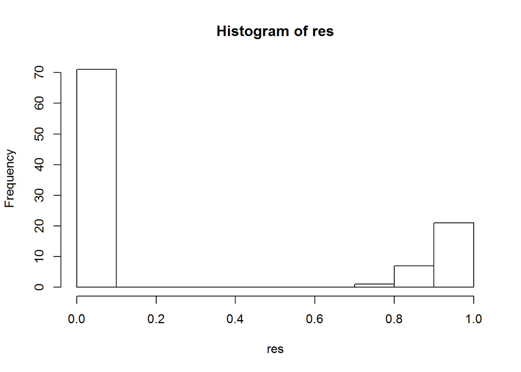

```r
n <- 100
res <- rep(0,n)
vec <- sample(1:1000, n)
for (i in 1:n)
{
  u <- testRANDU(1000, vec[i])
  res[i] <- Frequency(u, 10)
}
hist(res)
```

### Standard Minimal

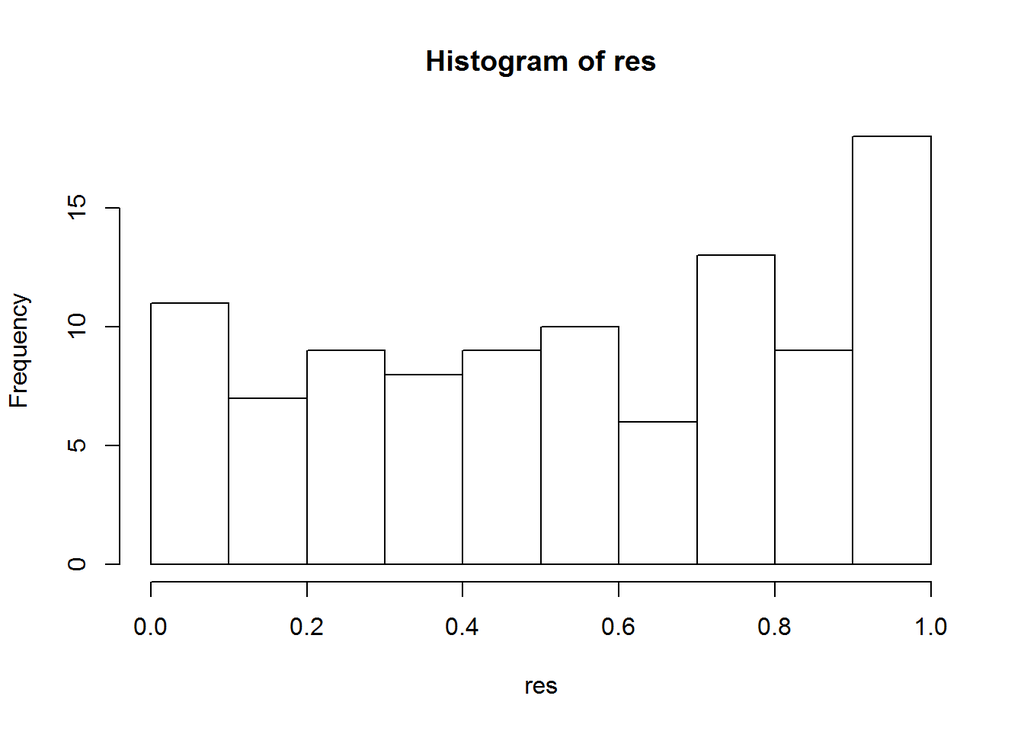

```r
n <- 100
res <- rep(0, n)
vec <- sample(1:1000, n)
for (i in 1:n)
{
  u <- testStandardMinimal(1000, vec[i])
  res[i] <- Frequency(u, 10)
}
hist(res)
```

### Mersenne-Twister

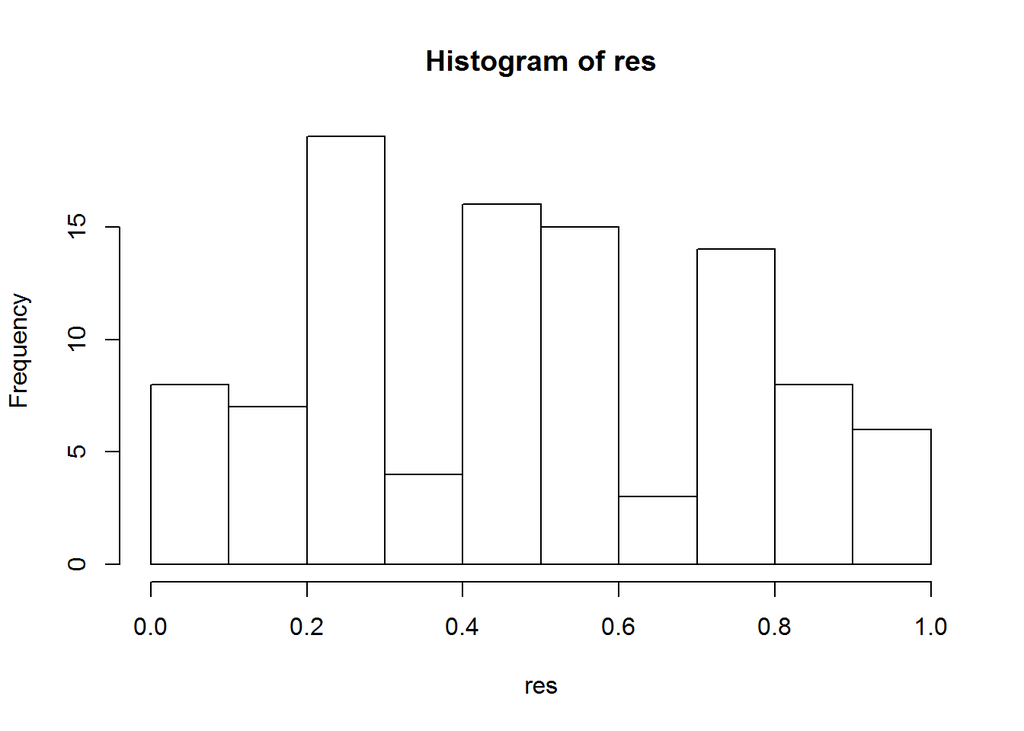

```r
n <- 100
res <- rep(0, n)
vec <- sample(1:1000, n)
for (i in 1:n)
{
  u <- (MersenneTwister(1000, p, vec[i]))$x
  res[i] <- Frequency(u, 10)
}
hist(res)
```

### Sobol

```r
n <- 100
p <- 1
u <- Sobol(n, p)
return (Frequency(u, 10))
```

```
## [1] 0.5270893
```

## Question 4 Test des Runs

### RANDU

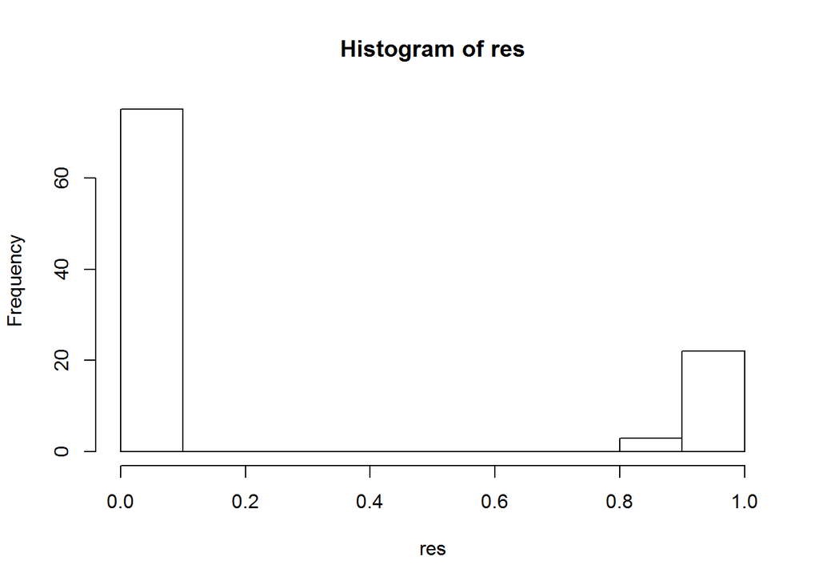

```r
n <- 100
res = rep(0,n)
vec <- sample(1:1000, n)
for (i in 1:n)
{
  u <- testRANDU(1000, vec[i])
  res[i] <- Runs(u, 10)
}
hist(res)
```

### Standard Minimal

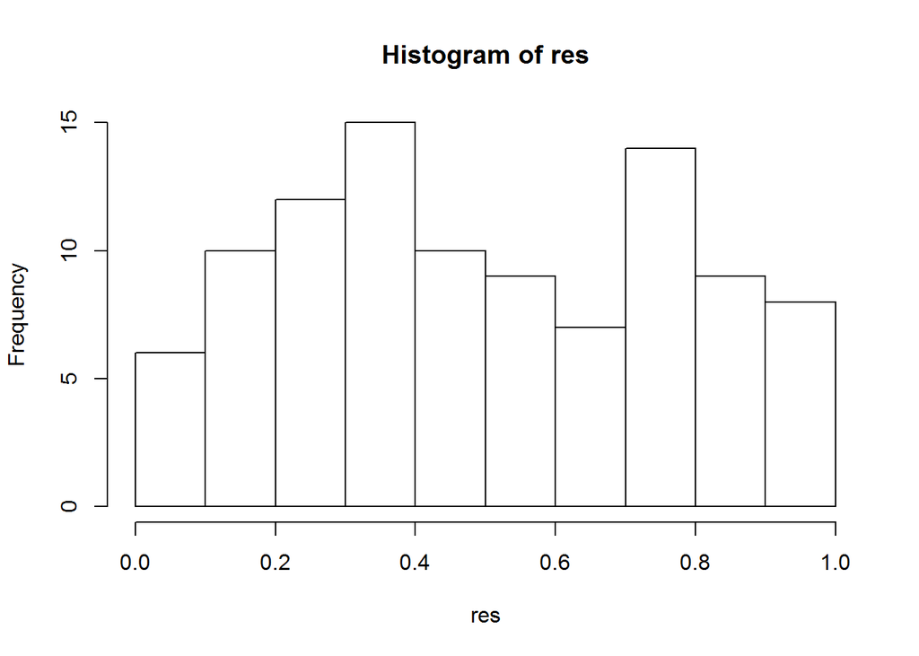

```r
n <- 100
res <- rep(0, n)
vec <- sample(1:1000, n)
for (i in 1:n)
{
  u <- testStandardMinimal(1000, vec[i])
  res[i] <- Runs(u, 10)
}
hist(res)
```

### Mersenne-Twister

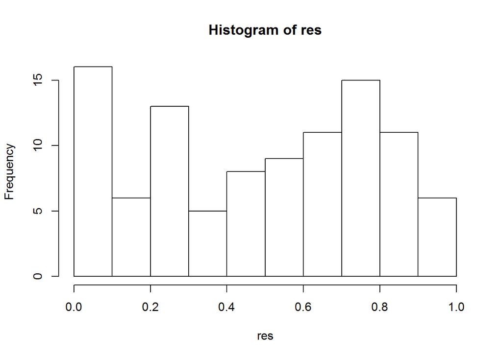

```r
n <- 100
res <- rep(0, n)
vec <- sample(1:1000, n)
for (i in 1:n)
{
  u <- (MersenneTwister(1000, p, vec[i]))$x
  res[i] <- Runs(u, 10)
}
hist(res)
```

### Sobol

```r
n <- 100
p <- 1
u <- Sobol(n, p)
return (Runs(u, 10))
```

```
## [1] 0
```

## Question 5 Test d’ordre

### RANDU

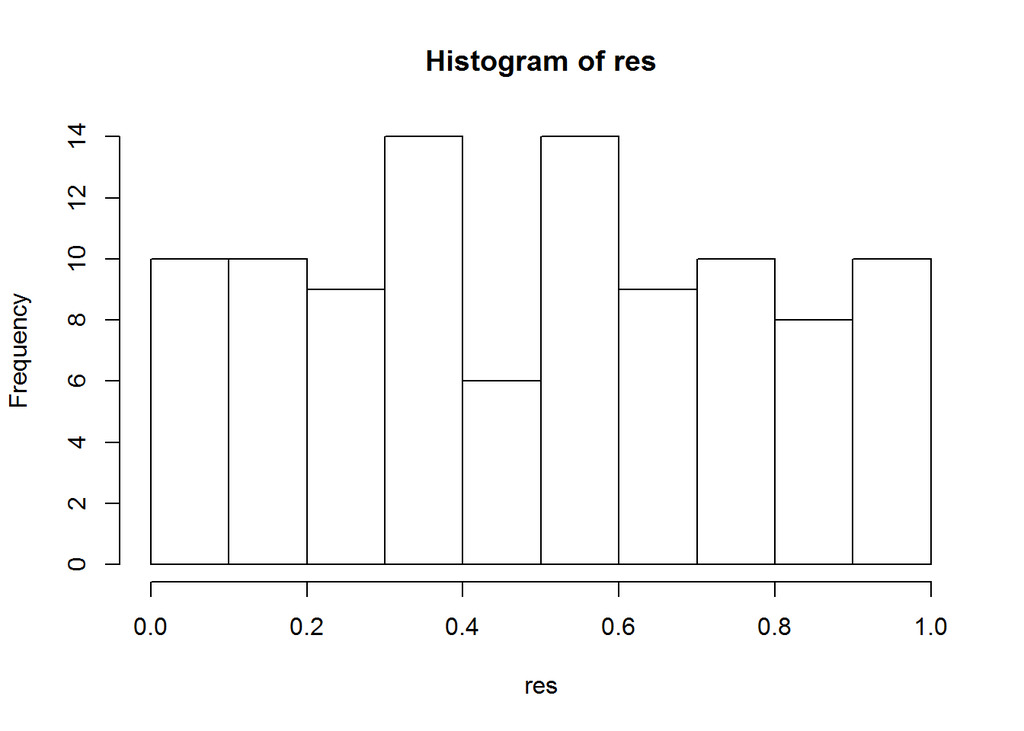

```r
n <- 100
res = rep(0,n)
vec <- sample(1:1000, n)
for (i in 1:n)
{
  u <- testRANDU(1000, vec[i])
  res[i] <- order.test(u, d=4, echo=FALSE)$p.value
}
hist(res)
```

### Standard Minimal

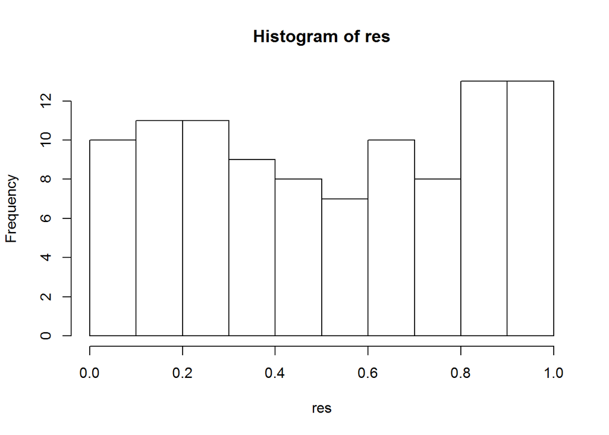

```r
n <- 100
res <- rep(0, n)
vec <- sample(1:1000, n)
for (i in 1:n)
{
  u <- testStandardMinimal(1000, vec[i])
  res[i] <- order.test(u, d=4, echo=FALSE)$p.value
}
hist(res)
```

### Mersenne-Twister

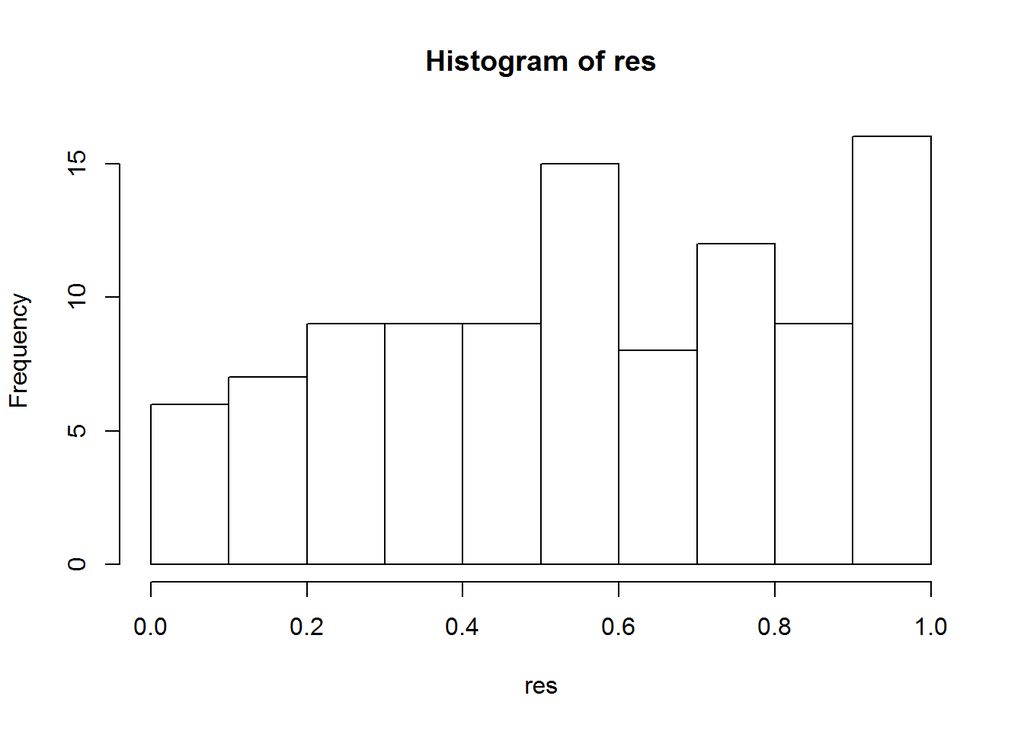

```r
n <- 100
res <- rep(0, n)
vec <- sample(1:1000, n)
for (i in 1:n)
{
  u <- (MersenneTwister(1000, p, vec[i]))$x
  res[i] <- order.test(u[,1], d=4, echo=FALSE)$p.value
}
hist(res)
```

### Sobol

```r
n <- 100
p <- 1
u <- Sobol(n, p)
return (order.test(u, d=4, echo=FALSE)$p.value)
```

```
## [1] 0.31
```

## Question 6

```r
LoiBinomiale <- function(n,p)
{
  succes <- 0
  for (i in 1:n)
  {
    if (runif(1) <= p)
    {
      succes <- succes + 1
    }
  }
  return (succes)
}
```

```r
PlotBinomiale <- function(n,p,precision=1000)
{
  vec = rep(0,precision)
  for (i in 1:precision)
  {
    vec[i] <- LoiBinomiale(n,p)
  }
  plot(table(vec))
}
```

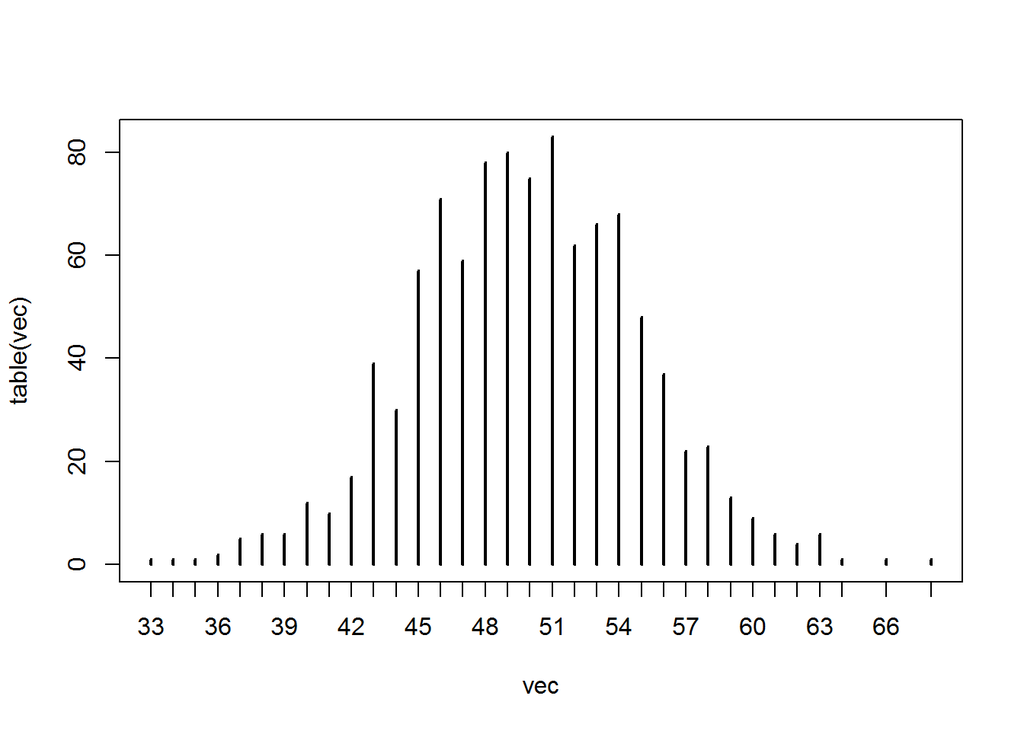

```r
PlotBinomiale(n=100, p=0.5)
```

## Question 7

```r
LoiNormale <- function(m,s)
{
  X <- sqrt(-log(runif(1)))*cos(2*pi*runif(1))
  X <- m + sqrt(s)*X
  return (X)
}
```

```r
PlotNormale <- function(m,s,precision=1000)
{
  vec = rep(0,precision)
  for (i in 1:precision)
  {
    vec[i] <- LoiNormale(m,s)
  }
  hist(vec)
}
```

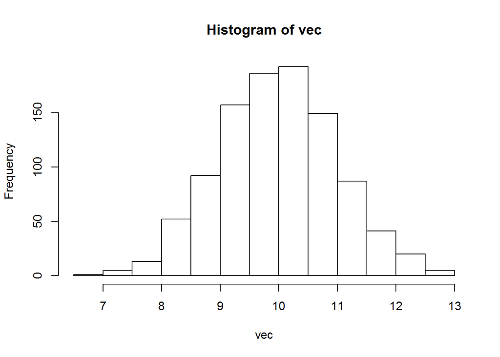

```r
PlotNormale(10,2)
```

## Question 8

```r
FileMM1 <- function(lambda, mu, D)
{
  arrivee <- c()
  depart <- c()

   time <- rexp(1, lambda)

  while (time < D)
  {
    arrivee <- c(arrivee, time)
    time <- time + rexp(1, lambda)
  }

  if (length(arrivee) > 0)
  {
    depart <- c(depart, arrivee[1] + rexp(1, mu))
    for (i in 2:length(arrivee))
    {
      if (arrivee[i] > depart [i-1]) # Quand le client i arrive, le client i-1 est déjà parti
        time = arrivee[i] + rexp(1, mu)
      else # Quand le client i arrive, il attend le départ de i-1
        time = depart[i-1] + rexp(1, mu)

      if (time < D)
        depart[i] = time
      else
        break
    }

  }
  return(list(arrivee,depart))
}
```